# NYC Taxi Fare Prediction using Pytorch

# Table of Contents

## Overview

### Introduction

The [New York City Taxi Fare Prediction Kaggle competition](https://www.kaggle.com/c/new-york-city-taxi-fare-prediction) provides a dataset with about 55 million records. The data contains features such as pickup date & time, the latitude & longitude (GPS coordinates) of the pickup and dropoff locations, and the number of passengers.

**Goal** - Our goal is to predict the `fare_amount` for a taxi ride given the gps coordinates, time and day of week etc.

**Data** - For this analysis, we will use the data from April'11 to April'24, 2010 (120,000 records). The data has been randomly sorted. Here are some details about the dataset:

**Features**

- pickup_datetime - timestamp value indicating when the taxi ride started.
- pickup_longitude - float for longitude coordinate of where the taxi ride started.
- pickup_latitude - float for latitude coordinate of where the taxi ride started.
- dropoff_longitude - float for longitude coordinate of where the taxi ride ended.
- dropoff_latitude - float for latitude coordinate of where the taxi ride ended.
- passenger_count - integer indicating the number of passengers in the taxi ride.

**Target**

- fare_amount - float dollar amount of the cost of the taxi ride. This value is only in the training set; this is what you are predicting in the test set and it is required in your submission CSV.

```python
# Import libraries

import torch
import torch.nn as nn

import numpy as np
import pandas as pd

import seaborn as sns
import matplotlib.pyplot as plt
%matplotlib inline
plt.style.use('ggplot')

plt.rcParams['font.size'] = 14
palette = sns.color_palette('hls', 10)
```

## Read the Data

```python
# Read the data
df = pd.read_csv('Data/NYCTaxiFares.csv')
df.shape
```

```
(120000, 8)
```

```python
# Check head
df.head()
```

|  | pickup_datetime | fare_amount | fare_class | pickup_longitude | pickup_latitude | dropoff_longitude | dropoff_latitude | passenger_count |
| --- | --- | --- | --- | --- | --- | --- | --- | --- |
| 0 | 2010-04-19 08:17:56 UTC | 6.5 | 0 | -73.992365 | 40.730521 | -73.975499 | 40.744746 | 1 |
| 1 | 2010-04-17 15:43:53 UTC | 6.9 | 0 | -73.990078 | 40.740558 | -73.974232 | 40.744114 | 1 |
| 2 | 2010-04-17 11:23:26 UTC | 10.1 | 1 | -73.994149 | 40.751118 | -73.960064 | 40.766235 | 2 |
| 3 | 2010-04-11 21:25:03 UTC | 8.9 | 0 | -73.990485 | 40.756422 | -73.971205 | 40.748192 | 1 |
| 4 | 2010-04-17 02:19:01 UTC | 19.7 | 1 | -73.990976 | 40.734202 | -73.905956 | 40.743115 | 1 |

```python
# Check data types
df.info()
```

```
<class 'pandas.core.frame.DataFrame'>
RangeIndex: 120000 entries, 0 to 119999
Data columns (total 8 columns):
pickup_datetime      120000 non-null object
fare_amount          120000 non-null float64
fare_class           120000 non-null int64
pickup_longitude     120000 non-null float64
pickup_latitude      120000 non-null float64
dropoff_longitude    120000 non-null float64
dropoff_latitude     120000 non-null float64
passenger_count      120000 non-null int64
dtypes: float64(5), int64(2), object(1)
memory usage: 7.3+ MB
```

```python
# Check fare amount
df['fare_amount'].describe()
```

```
count    120000.000000
mean         10.040326
std           7.500134
min           2.500000
25%           5.700000
50%           7.700000
75%          11.300000
max          49.900000
Name: fare_amount, dtype: float64
```

> We can see that fares range from \$2.50 to \\$49.90, with a mean of \$10.04 and a median of \\$7.70

## Feature Engineering

In this section, we will:

- Calculate distance between pickup and dropoff locations.
- Adjust the time to reflect Eastern time zone.
- Extract hour, day of the weeek and am/pm information from datetime columns.
- Convert categorical columns to `category` type.

### Calculate distance

Calculate the distance between pickup and dropoff locations using Haversine Distance. The formula is:

${\displaystyle d=2r\arcsin \left({\sqrt {\sin ^{2}\left({\frac {\varphi _{2}-\varphi _{1}}{2}}\right)+\cos(\varphi _{1})\:\cos(\varphi _{2})\:\sin ^{2}\left({\frac {\lambda _{2}-\lambda _{1}}{2}}\right)}}\right)}$

where

$\begin{split} r&: \textrm {radius of the sphere (Earth's radius averages 6371 km)}\\ \varphi_1, \varphi_2&: \textrm {latitudes of point 1 and point 2}\\ \lambda_1, \lambda_2&: \textrm {longitudes of point 1 and point 2}\end{split}$

```python
def haversine_distance(df, lat1, long1, lat2, long2):
    """
    Calculates the haversine distance between 2 sets of GPS coordinates in df
    """
    r = 6371  # average radius of Earth in kilometers

    phi1 = np.radians(df[lat1])
    phi2 = np.radians(df[lat2])

    delta_phi = np.radians(df[lat2]-df[lat1])
    delta_lambda = np.radians(df[long2]-df[long1])

    a = np.sin(delta_phi/2)**2 + np.cos(phi1) * np.cos(phi2) * np.sin(delta_lambda/2)**2
    c = 2 * np.arctan2(np.sqrt(a), np.sqrt(1-a))
    d = (r * c) # in kilometers

    return d
```

```python
df['dist_km'] = haversine_distance(df,'pickup_latitude','pickup_longitude','dropoff_latitude','dropoff_longitude')
df.head()
```

|  | pickup_datetime | fare_amount | fare_class | pickup_longitude | pickup_latitude | dropoff_longitude | dropoff_latitude | passenger_count | dist_km |
| --- | --- | --- | --- | --- | --- | --- | --- | --- | --- |
| 0 | 2010-04-19 08:17:56 UTC | 6.5 | 0 | -73.992365 | 40.730521 | -73.975499 | 40.744746 | 1 | 2.126312 |
| 1 | 2010-04-17 15:43:53 UTC | 6.9 | 0 | -73.990078 | 40.740558 | -73.974232 | 40.744114 | 1 | 1.392307 |
| 2 | 2010-04-17 11:23:26 UTC | 10.1 | 1 | -73.994149 | 40.751118 | -73.960064 | 40.766235 | 2 | 3.326763 |
| 3 | 2010-04-11 21:25:03 UTC | 8.9 | 0 | -73.990485 | 40.756422 | -73.971205 | 40.748192 | 1 | 1.864129 |
| 4 | 2010-04-17 02:19:01 UTC | 19.7 | 1 | -73.990976 | 40.734202 | -73.905956 | 40.743115 | 1 | 7.231321 |

### Extract date time columns

Here, we will extract information like "day of the week", "am vs. pm" etc. The original data was saved in UTC time ans so we'll make an adjustment to EDT using UTC-4 (subtracting 4 hours).

```python
# Convert to datetime in EDT
df['EDTdate'] = pd.to_datetime(df['pickup_datetime']) - pd.Timedelta(hours=4)
```

```python
# Check head
df.head()
```

|  | pickup_datetime | fare_amount | fare_class | pickup_longitude | pickup_latitude | dropoff_longitude | dropoff_latitude | passenger_count | dist_km | EDTdate |
| --- | --- | --- | --- | --- | --- | --- | --- | --- | --- | --- |
| 0 | 2010-04-19 08:17:56 UTC | 6.5 | 0 | -73.992365 | 40.730521 | -73.975499 | 40.744746 | 1 | 2.126312 | 2010-04-19 04:17:56+00:00 |
| 1 | 2010-04-17 15:43:53 UTC | 6.9 | 0 | -73.990078 | 40.740558 | -73.974232 | 40.744114 | 1 | 1.392307 | 2010-04-17 11:43:53+00:00 |
| 2 | 2010-04-17 11:23:26 UTC | 10.1 | 1 | -73.994149 | 40.751118 | -73.960064 | 40.766235 | 2 | 3.326763 | 2010-04-17 07:23:26+00:00 |
| 3 | 2010-04-11 21:25:03 UTC | 8.9 | 0 | -73.990485 | 40.756422 | -73.971205 | 40.748192 | 1 | 1.864129 | 2010-04-11 17:25:03+00:00 |
| 4 | 2010-04-17 02:19:01 UTC | 19.7 | 1 | -73.990976 | 40.734202 | -73.905956 | 40.743115 | 1 | 7.231321 | 2010-04-16 22:19:01+00:00 |

### Add columns for hour, day of week and am/pm

```python
# Add hour
df['Hour'] = df['EDTdate'].dt.hour
```

```python
# Add AM/PM
df['AMorPM'] = np.where(df['Hour']<12,'am','pm')
```

```python
# Add Weekday
df['Weekday'] = df['EDTdate'].dt.strftime("%a")
```

```python
# Check head
df.head()
```

|  | pickup_datetime | fare_amount | fare_class | pickup_longitude | pickup_latitude | dropoff_longitude | dropoff_latitude | passenger_count | dist_km | EDTdate | Hour | AMorPM | Weekday |
| --- | --- | --- | --- | --- | --- | --- | --- | --- | --- | --- | --- | --- | --- |
| 0 | 2010-04-19 08:17:56 UTC | 6.5 | 0 | -73.992365 | 40.730521 | -73.975499 | 40.744746 | 1 | 2.126312 | 2010-04-19 04:17:56+00:00 | 4 | am | Mon |
| 1 | 2010-04-17 15:43:53 UTC | 6.9 | 0 | -73.990078 | 40.740558 | -73.974232 | 40.744114 | 1 | 1.392307 | 2010-04-17 11:43:53+00:00 | 11 | am | Sat |
| 2 | 2010-04-17 11:23:26 UTC | 10.1 | 1 | -73.994149 | 40.751118 | -73.960064 | 40.766235 | 2 | 3.326763 | 2010-04-17 07:23:26+00:00 | 7 | am | Sat |
| 3 | 2010-04-11 21:25:03 UTC | 8.9 | 0 | -73.990485 | 40.756422 | -73.971205 | 40.748192 | 1 | 1.864129 | 2010-04-11 17:25:03+00:00 | 17 | pm | Sun |
| 4 | 2010-04-17 02:19:01 UTC | 19.7 | 1 | -73.990976 | 40.734202 | -73.905956 | 40.743115 | 1 | 7.231321 | 2010-04-16 22:19:01+00:00 | 22 | pm | Fri |

```python
# Check min and max dates
print(min(df['EDTdate']))
print(max(df['EDTdate']))
```

```
2010-04-11 00:00:10+00:00
2010-04-24 23:59:42+00:00
```

## Data Exploration

Let's explore the data.

### Distribution of Fare Amount

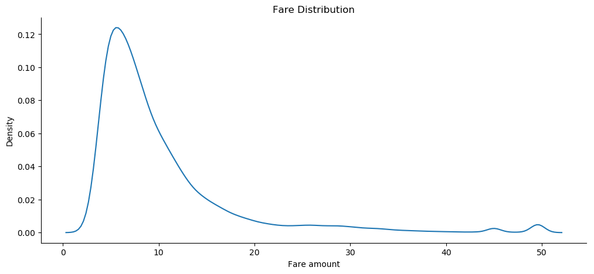

```python
# Distribution of fare amount
plt.figure(figsize=(12,5))
sns.kdeplot(df['fare_amount'])
sns.despine()
plt.xlabel('Fare amount')
plt.ylabel('Density')
plt.title('Fare Distribution')
plt.show()
```

> The plot is heavily skewed to the right showing that majority of fare amounts are around $6 with a steep decline indicating that most trips were for a short distance. There are a couple of larger fare amounts indicating longer trips (possibly to the JFK airport... just a wild guess).

### Distribution of Passengers

```python
# Distribution of passenger count
plt.figure(figsize=(12,5))
sns.catplot(x='passenger_count', kind='count', data=df,
            aspect=2.5, palette="icefire")
sns.despine()
plt.title('Passenger Count');
```

[output not shown]

### Trips by Day of the Week

[figure not shown]

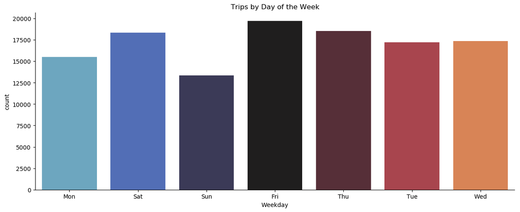

```python
# Trips by day of the week
plt.figure(figsize=(12,5))
sns.catplot(x='Weekday', kind='count', data=df,
            aspect=2.5, palette="icefire")
sns.despine()
plt.title('Trips by Day of the Week')
plt.show()
```

### Trips by Hour of the Day

```python
# Trips by hour of the day
plt.figure(figsize=(12,5))
sns.catplot(x='Hour', kind='count', data=df,
            aspect=2.5, palette="icefire")
sns.despine()
plt.title('Trips by Hour of the Day');
```

[output not shown]

### Trips by Day of the Week and Hour

[figure not shown]

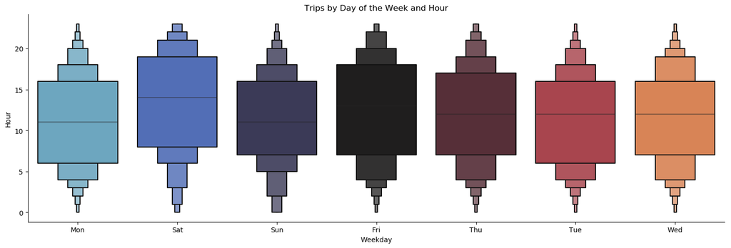

```python
plt.figure(figsize=(12,5))
sns.catplot(x='Weekday',y='Hour',data=df, aspect=3, kind='boxen', palette="icefire")
plt.title('Trips by Day of the Week and Hour')
plt.show()
```

### Distribution of Trip Distance

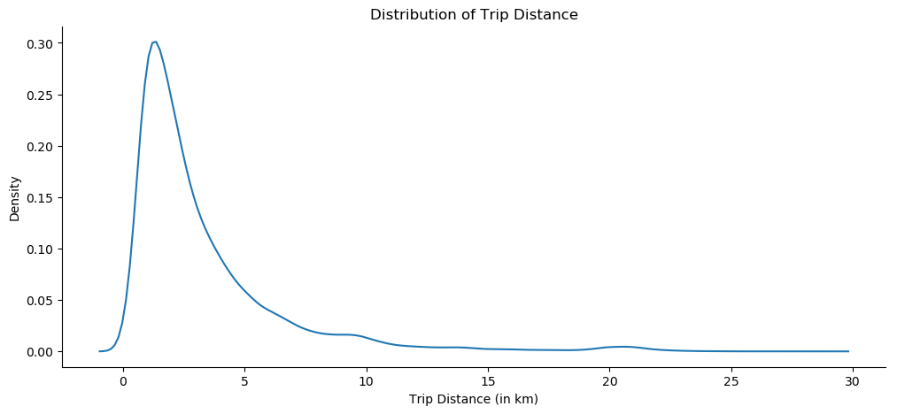

```python
# Distribution of Trip Distance
plt.figure(figsize=(12,5))
sns.kdeplot(df['dist_km'])
sns.despine()
plt.xlabel('Trip Distance (in km)')
plt.ylabel('Density')
plt.title('Distribution of Trip Distance')
plt.show()
```

> The plot is heavily skewed to the right indicating that majority of the trips taken were for a short distance. There are a couple of blips at around 10 km and 20 km mark indicating longer trips (possibly to the JFK airport... just a wild guess).

### Distance travelled by Weekday and AM/PM

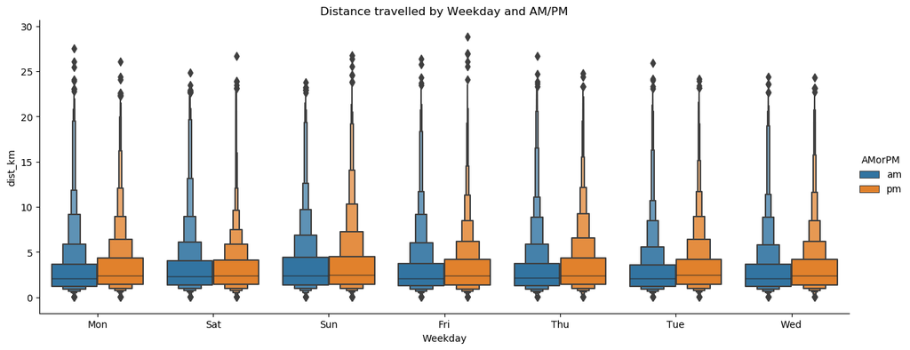

```python
sns.catplot(x='Weekday',y='dist_km',data=df, aspect=2.5, hue='AMorPM', kind='boxen')
plt.title('Distance travelled by Weekday and AM/PM')
plt.show()
```

> The plot shows that trips were longer (in km) on Friday, Sunday in the PM and Monday morning. Thats is also the time when most people travel to the airport. IQR range for trips show that people travelled a little further in the later half of the day (PM) than in the morning.

### Distance travelled by Day and Hour

While the plot below may look difficult to intepret, we are only interested in the trend of distance for each day focusing on the median distance travelled.

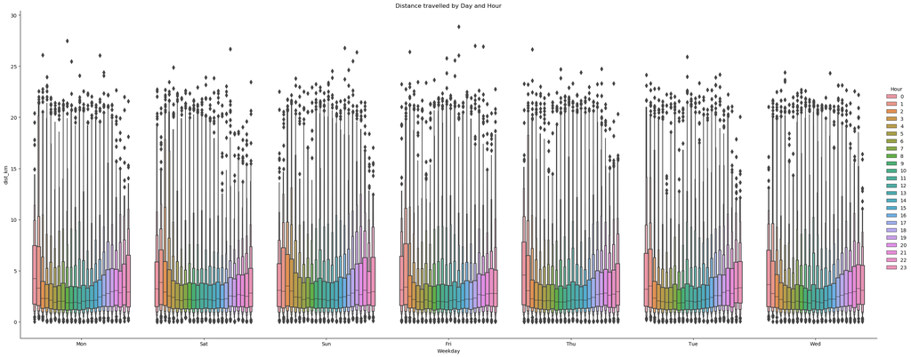

```python
# Create plot
plt.figure(figsize=(15,10))
sns.catplot(x='Weekday', y='dist_km',data=df, aspect=2.5, hue='Hour', height=10, kind='boxen')
plt.title('Distance travelled by Day and Hour')
plt.show()
```

> The plot shows that the median distance travelled was more at around 12am on Modanys and Thrusdays. We can also see the trend for median distance travelled increasing in the evenings for Monday, Tuesday and Wednesdays.

### Fare Amount by Day and Hour

While the plot below may look difficult to intepret, we are only interested in the trend of fare amount for each day focusing on the median amount.

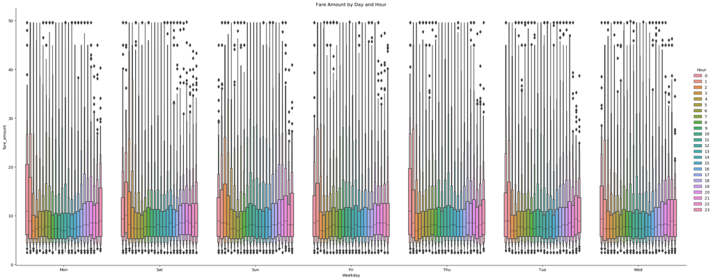

```python
# Plot
plt.figure(figsize=(15,10))
sns.catplot(x='Weekday',y='fare_amount',data=df, aspect=2.5, hue='Hour', kind='boxen', height=10)
plt.title('Fare Amount by Day and Hour')
plt.show()
```

> The trend for median fare amounts seems to follow the median distance travelled. The plot shows that the median fare amount was more at around 12am on Modanys and Thrusdays. We can also see the trend for median fare amount increasing in the evenings for Monday, Tuesday and Wednesdays.

### Fare amount by Distance

```python
# Plot
sns.jointplot(x='fare_amount', y='dist_km', data=df);
```

[output not shown]

## Categorify the data

Convert categorical columns to `category` type.

### Separate categorical and continous columns

```python
# Check data types
df.dtypes
```

```
pickup_datetime                   object
fare_amount                      float64
fare_class                         int64
pickup_longitude                 float64
pickup_latitude                  float64
dropoff_longitude                float64
dropoff_latitude                 float64
passenger_count                    int64
dist_km                          float64
EDTdate              datetime64[ns, UTC]
Hour                               int64
AMorPM                            object
Weekday                           object
dtype: object
```

```python
# Identify categorical columns
cat_cols = ['Hour', 'AMorPM', 'Weekday']

# Identify continous columns
cont_cols = ['pickup_latitude', 'pickup_longitude', 'dropoff_latitude', 'dropoff_longitude', 'passenger_count', 'dist_km']

# Identify the target/response variable
y_col = ['fare_amount']  # this column contains the labels
```

### Convert columns to category type

```python
# Convert our three categorical columns to category dtypes
for col in cat_cols:
    df[col] = df[col].astype('category')
```

```python
# Check data types
df.dtypes
```

```
pickup_datetime                   object
fare_amount                      float64
fare_class                         int64
pickup_longitude                 float64
pickup_latitude                  float64
dropoff_longitude                float64
dropoff_latitude                 float64
passenger_count                    int64
dist_km                          float64
EDTdate              datetime64[ns, UTC]
Hour                            category
AMorPM                          category
Weekday                         category
dtype: object
```

```python
# Check categories for Hour
df['Hour'].cat.categories
```

```
Int64Index([ 0,  1,  2,  3,  4,  5,  6,  7,  8,  9, 10, 11, 12, 13, 14, 15, 16,
            17, 18, 19, 20, 21, 22, 23],
           dtype='int64')
```

> Here our categorical names are the integers 0 through 23, for a total of 24 unique categories. These values also correspond to the codes assigned to each name.

```python
# Check categories for AMorPM
df['AMorPM'].cat.categories
```

```
Index(['am', 'pm'], dtype='object')
```

```python
# Check categories for AMorPM
df['Weekday'].cat.categories
```

```
Index(['Fri', 'Mon', 'Sat', 'Sun', 'Thu', 'Tue', 'Wed'], dtype='object')
```

```python
# Check codes of categories for AMorPM
df['AMorPM'].head().cat.codes
```

```
0    0
1    0
2    0
3    1
4    1
dtype: int8
```

### Combine categorical columns

Here, we will combine the three columns into a single array.

```python
# Combine categorical cols into an array
cats_comb = np.stack([df[col].cat.codes.values for col in cat_cols], 1)
```

```python
# Check shape
cats_comb.shape
```

```
(120000, 3)
```

## Tensors and Embeddings

### Create tensors for categorical and continous data

```python
# Convert categorical columns to a tensor
cats_comb = torch.tensor(cats_comb, dtype=torch.int64)
```

```python
# Check type and shape
print(cats_comb.type())
print(cats_comb.shape)
```

```
torch.LongTensor
torch.Size([120000, 3])
```

```python
# Convert continous columns to tensor
cont_comb = np.stack([df[col].values for col in cont_cols], 1)
cont_comb = torch.tensor(cont_comb, dtype=torch.float)
cont_comb[:5]
```

```
tensor([[ 40.7305, -73.9924,  40.7447, -73.9755,   1.0000,   2.1263],
        [ 40.7406, -73.9901,  40.7441, -73.9742,   1.0000,   1.3923],
        [ 40.7511, -73.9941,  40.7662, -73.9601,   2.0000,   3.3268],
        [ 40.7564, -73.9905,  40.7482, -73.9712,   1.0000,   1.8641],
        [ 40.7342, -73.9910,  40.7431, -73.9060,   1.0000,   7.2313]])
```

```python
# Check type and shape
print(cont_comb.type())
print(cont_comb.shape)
```

```
torch.FloatTensor
torch.Size([120000, 6])
```

```python
# Convert response variable to a tensor
y = torch.tensor(df[y_col].values, dtype=torch.float).reshape(-1,1)
y.shape
```

```
torch.Size([120000, 1])
```

### Set Embedding Sizes (One hot encoding for categorical data)

Embeddings in a tensor are like one-hot encoding for categorical variables. The rule of thumb for determining the embedding size is to divide the number of unique entries in each column by 2, but not to exceed 50.

```python
# Check size of categories in different categorical columns
cat_szs = [len(df[col].cat.categories) for col in cat_cols]
cat_szs
```

```
[24, 2, 7]
```

```python
# Set embedding sizes
emb_szs = [(size, min(50, (size+1)//2)) for size in cat_szs]
emb_szs
```

```
[(24, 12), (2, 1), (7, 4)]
```

## Build the Model

### Define Tabular Model

Here we will define a `TabularModel()` class that follows the [fast.ai library](https://docs.fast.ai/tabular.models.html). The goal is to define a model based on the number of continuous columns (given by `conts.shape[1]`) plus the number of categorical columns and their embeddings (given by `len(emb_szs)` and `emb_szs` respectively).

A **Fully Connected Network** with 3 hidden layers of size [200,300,200] will be used. On each layer, we will:

- Use `ReLu` activation function
- Normalize the layer
- Use a dropout layer to randomly drop 40% of the data.

```python
class TabularModel(nn.Module):

    def __init__(self, emb_szs, n_cont, layers, n_out, p=0.5):
        super().__init__()

        # setup embeddings list
        # Categorical data will be filtered through these Embeddings in the forward section
        self.embeds = nn.ModuleList([nn.Embedding(ni,nf) for ni,nf in emb_szs])

        # setup dropout for embeddings
        self.emb_drop = nn.Dropout(p)

        # normalize continous variables
        self.bn_cont = nn.BatchNorm1d(n_cont)

        # combine categorical and continous sizes to determine final input size
        n_emb = sum([nf for ni,nf in emb_szs])
        n_in = n_cont + n_emb

        # Create network of layers
        layerlist = []

        """
        the code below:
        - iterates over neuron sizes and creates hidden layers where each layer
        is a linear layer with Relu actovation.
        - gets normalized and then we do Dropout (randomly assign 0's to x% data) to avoid overfitting
        size of input gets updated to neurons in the hidden layer we just iterated over.

        Sizes are as follows:
        e.g. if we decide to create 3 hidden layers with 200, 500, 100 neurons, then
        layers = [200, 500, 100]
        size of input = n_in
        size of hidden layer 1 = n_in x 200
        size of hidden layer 2 = 200 x 500
        size of hidden layer 3 = 500 x 100
        size of final Linear layer = 500 x 1
        """
        for i in layers:
            layerlist.append(nn.Linear(n_in, i))
            layerlist.append(nn.ReLU(inplace=True))
            layerlist.append(nn.BatchNorm1d(i))
            layerlist.append(nn.Dropout(p))
            n_in = i

        # last layer is a linear layer of size(neurons in last layer in layers, n_out)
        layerlist.append(nn.Linear(layers[-1], n_out))

        # Combine list of layers together
        self.layers = nn.Sequential(*layerlist)

    def forward(self, x_cats, x_cont):
        embeddings = []

        # Pass data through embedding layers
        for i,e in enumerate(self.embeds):
            embeddings.append(e(x_cats[:,i]))

        # concatenate embeddings into a tensor
        cat_var = torch.cat(embeddings, dim=1)

        # Use dropout to randomly assign 0's to x% data in embeddings
        cat_var = self.emb_drop(cat_var)

        # Normalize continous variables
        cont_var = self.bn_cont(x_cont)

        # Concatenate categorical and continous variables
        x = torch.cat([cat_var, cont_var], 1)

        # Create list of layers
        x = self.layers(x)
        return x
```

### Build Model

```python
# Build model
torch.manual_seed(33)
model = TabularModel(emb_szs, cont_comb.shape[1], layers=[200,300,200], n_out=1, p=0.4)
```

```python
# See model details
model
```

```
TabularModel(
  (embeds): ModuleList(
    (0): Embedding(24, 12)
    (1): Embedding(2, 1)
    (2): Embedding(7, 4)
  )
  (emb_drop): Dropout(p=0.4)
  (bn_cont): BatchNorm1d(6, eps=1e-05, momentum=0.1, affine=True, track_running_stats=True)
  (layers): Sequential(
    (0): Linear(in_features=23, out_features=200, bias=True)
    (1): ReLU(inplace)
    (2): BatchNorm1d(200, eps=1e-05, momentum=0.1, affine=True, track_running_stats=True)
    (3): Dropout(p=0.4)
    (4): Linear(in_features=200, out_features=300, bias=True)
    (5): ReLU(inplace)
    (6): BatchNorm1d(300, eps=1e-05, momentum=0.1, affine=True, track_running_stats=True)
    (7): Dropout(p=0.4)
    (8): Linear(in_features=300, out_features=200, bias=True)
    (9): ReLU(inplace)
    (10): BatchNorm1d(200, eps=1e-05, momentum=0.1, affine=True, track_running_stats=True)
    (11): Dropout(p=0.4)
    (12): Linear(in_features=200, out_features=1, bias=True)
  )
)
```

## Train and Test the Model

### Split the data

```python
# Setup batch and test size
batch_size = 60000
test_size = int(batch_size * 0.2)
```

```python
# Create splits
cont_train = cont_comb[:batch_size-test_size]
cont_test = cont_comb[batch_size-test_size:batch_size]
cat_train = cats_comb[:batch_size-test_size]
cat_test = cats_comb[batch_size-test_size:batch_size]

# For response variable
y_train = y[:batch_size-test_size]
y_test = y[batch_size-test_size:batch_size]
```

```python
# Check train, test lengths
print(len(cont_train))
print(len(cont_test))
```

```
48000
12000
```

### Define loss function and optimizer

```python
# Define loss and optimizer
criterion = nn.MSELoss()
optimizer = torch.optim.Adam(model.parameters(), lr=0.001)
```

### Train the Model

Here, we will train the model for 300 epochs and optimize using the `Adam` optimizer.

```python
%%time

epochs = 300
losses = []

for i in range(epochs):
    i += 1
    # generate prediction
    y_pred = model(cat_train, cont_train)
    # compute loss
    loss = torch.sqrt(criterion(y_pred, y_train))
    losses.append(loss)

    if i%10 == 1:
        print(f'epoch: {i:3}  loss: {loss.item():10.8f}')

    # backprop
    optimizer.zero_grad()
    loss.backward()
    optimizer.step()

print(f'epoch: {i:3}  loss: {loss.item():10.8f}') # print loss for last epoch
```

```
epoch:   1  loss: 12.55616188
epoch:  11  loss: 11.54192066
epoch:  21  loss: 10.93466187
epoch:  31  loss: 10.50934124
epoch:  41  loss: 10.15295029
epoch:  51  loss: 9.84051609
epoch:  61  loss: 9.50658894
epoch:  71  loss: 9.12140083
epoch:  81  loss: 8.67223740
epoch:  91  loss: 8.12860489
epoch: 101  loss: 7.53865576
epoch: 111  loss: 6.87278032
epoch: 121  loss: 6.14578295
epoch: 131  loss: 5.40913677
epoch: 141  loss: 4.70694065
epoch: 151  loss: 4.10182142
epoch: 161  loss: 3.70679307
epoch: 171  loss: 3.56206393
epoch: 181  loss: 3.50243330
epoch: 191  loss: 3.46999526
epoch: 201  loss: 3.45166826
epoch: 211  loss: 3.42403889
epoch: 221  loss: 3.39421129
epoch: 231  loss: 3.40854263
epoch: 241  loss: 3.38766265
epoch: 251  loss: 3.33984447
epoch: 261  loss: 3.33268213
epoch: 271  loss: 3.33059573
epoch: 281  loss: 3.32077336
epoch: 291  loss: 3.30195522
epoch: 300  loss: 3.30223155
CPU times: user 1h 25min 9s, sys: 4min 5s, total: 1h 29min 15s
Wall time: 13min 28s
```

#### Plot Training Loss

```python
plt.plot(range(epochs), losses)
plt.ylabel('RMSE Loss')
plt.xlabel('epoch');
```

[output not shown]

### Validate the Model

Here, we will validate the model on test data.

```python
with torch.no_grad():
    # Generate prediction
    y_val = model(cat_test, cont_test)
    # Compute loss
    loss = torch.sqrt(criterion(y_val, y_test))
print(f'RMSE: {loss:.8f}')
```

```
RMSE: 3.24607873
```

> This means that on average, predicted values are within ±$3.2 of the actual value.

Now let's look at the first 20 predicted values:

```python
print(f'{"PREDICTED":>12} {"ACTUAL":>8} {"DIFF":>8}')
for i in range(20):
    diff = np.abs(y_val[i].item()-y_test[i].item())
    print(f'{i+1:2}. {y_val[i].item():8.4f} {y_test[i].item():8.4f} {diff:8.4f}')
```

```
   PREDICTED   ACTUAL     DIFF
 1.   5.2433   2.9000   2.3433
 2.  23.3398   5.7000  17.6398
 3.   5.7719   7.7000   1.9281
 4.  13.4511  12.5000   0.9511
 5.   5.1976   4.1000   1.0976
 6.   6.6128   5.3000   1.3128
 7.   3.3402   3.7000   0.3598
 8.  17.9253  14.5000   3.4253
 9.   4.5816   5.7000   1.1184
10.  11.3231  10.1000   1.2231
11.   7.0768   4.5000   2.5768
12.   6.2211   6.1000   0.1211
13.   6.5000   6.9000   0.4000
14.  13.2582  14.1000   0.8418
15.   5.6556   4.5000   1.1556
16.  40.2175  34.1000   6.1175
17.   2.2090  12.5000  10.2910
18.   5.2140   4.1000   1.1140
19.  10.4609   8.5000   1.9609
20.   5.8903   5.3000   0.5903
```

### Save the Model

Here, we will save the state of the model (weights & biases) and not the full definition.

```python
if len(losses) == epochs:
    torch.save(model.state_dict(), 'TaxiFareRegModel.pt')
    print('Model saved')
else:
    print('Model has not been trained. Consider loading a trained model instead.')
```

```
Model saved
```

## Summary

In this project, we used **PyTorch** to predict taxi fare precies for the NY taxi fare dataset. We built a `TabularModel()` class to handle both categorical and continous variables. A **Fully Connected Network** with 3 hidden layers of size [200,300,200] was used. `ReLu` activation function was used on each layer, the layer was normalized and then a dropout layer was used to randomly drop 40% of the data. The model was run for 300 epochs resulting in an RMSE of 3.24.